# Recursive Bayesian Methods

Alexander Berliner

2025-04-14

## (i) Simulating Data from a Logistic Regression Model with Synthetic Predictors

Logistic regression is a binary classifier. We want to find the probability that the observation $P(y = 1 \mid \mathbf{x})$ is a member of a class.

Along with the training set $\mathbf{X}$, we have a vector $\boldsymbol{\beta}$ of weights for each feature, including the intercept. The resulting evidence for the class is given by:

$$z = \mathbf{X} \boldsymbol{\beta}$$

To convert $z$ into a probability, we pass it through the sigmoid (logistic) function:

$$\sigma(z) = \frac{1}{1 + e^{-z}}$$

Reference: https://web.stanford.edu/~jurafsky/slp3/5.pdf

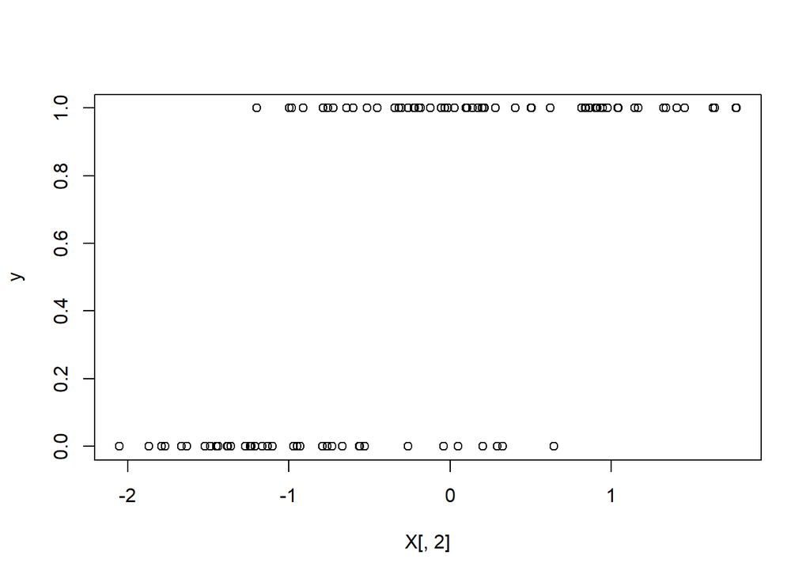

```r
n = 100 #number of observations
p = 1 #number of predictors

X <- cbind(1, matrix(rnorm(n * p), n, p))  # Design matrix with intercept (bias). nxp
beta <- c(1, 2)  # True coefficients. px1

z <- X %*% beta  # Linear predictor. %*% = matrix mult. nx1 dim
sig <- 1/(1+exp(-z)) #sigmoid (inv-logit) function, find probability in [0,1], predicted y

y = rbinom(n=n, size=1, prob=sig) #size=num trials=1 -> bernoulli response var

plot(X[,2],y)
```

## (ii) Sample from the posterior distribution of the regression coefficients using conventional Bayesian methods.

As our goal is to compute the probability of the model given the data, we use Markov Chain Monte Carlo (MCMC) as our simulation (stochastic) method to obtain random samples of $\beta$.

Some notes:

- The Bayesian treatment views $\beta$ as a random variable with a prior distribution. In this example, $y\vert\beta\sim F_y$ with unkown parameter coeficients $\beta\sim F_\beta$. If there were external parameters influencing the coefficients, than those parameters would be the hyperparamters. This is inline with the practice of **Bayesian hierarchical modeling**.
- Our goal is to find the distribution $p(\beta\vert y, X)$. Bayes’ rule for the posterior over the parameters is:
  $$p(\beta\vert y, X) = \frac{p(y\vert X,\beta)p(\beta)}{\int p(y\vert
  X,\beta)p(\beta)d\beta}$$
  where $p(y\vert X,\beta)$ is the likelihood, $p(\beta)$ is the prior, and the denominator is the marginal likelihood. As the integral may not be analytically solvable we resort to MCMC.
- **Importance sampling**: used for computing the expectation $E[\beta\vert y, X]$ by drawing from an approximation of the target distribution $p(\beta\vert y,X)$. Let $g(\beta)$ be the pdf of our sampling distribution (ie proposal distribution in MCMC). Then
  $$E[\beta\vert y, X] = \frac{\int\beta\cdot p(y\vert
  X,\beta)p(\beta)d\beta}{\int p(y\vert X,\beta)p(\beta)d\beta} =
  \frac{\int [\beta\cdot p(y\vert X,\beta)p(\beta)g(\beta)]/g(\beta)
  d\beta}{\int [p(y\vert X,\beta)p(\beta)g(\beta)]/g(\beta)d\beta}$$
  can be estimated using $S$ draws $\beta^1,\ldots,\beta^2$ from $g(\beta)$ by
  $$\frac{\frac{1}{S}\sum_{s=1}^S\beta^sw(\beta^s)}{\frac{1}{S}\sum_{s=1}^Sw(\beta^s)}$$
  $$w(\beta^s) = \frac{p(y\vert X,\beta^s)p(\beta^s)}{g(\beta^s)}$$
  are the importance ratios (weights).
- **Markov chain**: sequential sampling, where the last value drawn depends on the previously sampled value; $\beta^{i}$ depends on $\beta^{i-1}$. Choose $\beta^i$ from the transition distribution $T_i(\beta^i\vert\beta^{i-1})$; $i$ is iteration number.

Ref: BDA3 Ch. 10,11

**Metropolis algorithm**:

1. State the initial values: $N$ total iterations, $M$ dimensions, and a $N$x$M$ matrix $b$ where the first row is our initial guess $\beta^0 = [\beta_1^0,\ldots,\beta_M^0]$, and the subsequent rows is the sequence of the Markov chain of samples.
2. At iteration $i$, propose a new sample $\beta_{prop}$ from a symmetric proposal distribution $J_i(\beta^*\vert\beta^{i-1})=J_i(\beta^{i-1}\vert\beta^*)$.
3. Compute the acceptance ratio at iteration $i$:
   $$r = \frac{P(\beta^*)}{P(\beta^{i-1})} = \frac{p(y\vert
   X,\beta^*)p(\beta^*)}{p(y\vert X,\beta^{i-1})p(\beta^{i-1})}$$

Define initial functions:

```r
#Proposal distro
proposal <- function(i, M, beta, a){
  distro = runif(M, beta[i-1,] - a, beta[i-1,] + a)
  return(distro)
}

# Log-likelihood function for logistic regression
logistic_ll <- function(beta, X, y) {
  z <- X %*% beta
  p <- 1 / (1 + exp(-z))
  loglike <- sum(y * log(p) + (1 - y) * log(1 - p))
  return(loglike)
}

# Log-prior of unknown parameter
log_prior <- function(beta) {
  prior = 1
  return(prior)
}
```

Metropolis implementation:

```r
#0) Initial values
a <- 1 #error in proposal distro
N <- 10000 #number of samples
M <- p+1 #dimensions
b <- matrix(0, nrow = N, ncol = M) #empty matrix to be filled with vals
b[1,] <- c(0,0)  # first value of beta in the Markov chain is (0,0).

for (i in 2:N) {
    #1) Propose new position beta[i-1] -> beta[i]' from proposal distro
    b_prop <- proposal(i, M, b, a)

    #2) Compute transition probability
    P_prop <- logistic_ll(b_prop, X, y)+log_prior(b_prop)  #P(beta*)
    P_prev <- logistic_ll(b[i-1,], X, y)+log_prior(b[i-1])  #P(beta^{i-1})

    #3) Acceptance ratio
    alpha <- min(exp(P_prop - P_prev), 1)

    #3) Generate a random number u_i from [0,1]
    u <- runif(1)  # u_i

    #4)
    if (u <= alpha) {
        b[i,] <- b_prop  # Accept y as next state
    } else {
        b[i,] <- b[i-1,]  # Stay at previous state of Markov chain
    }
}

n <- as.integer(0.95 * N)
C <- b[(N - n + 1):N,] #discard first 5% of samples
```

$\beta_1$ distro estimate:

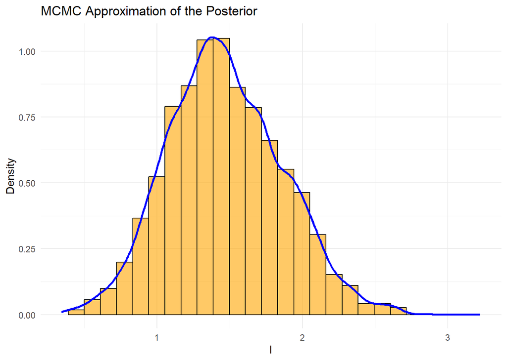

```r
c = C[,1]
# Plot of density function
library(ggplot2)
nbins <- ceiling( (2*n)**(1/3) ) #Terrell-Scott rule for min num bins
ggplot() +
  geom_histogram(aes(x = c, y = ..density..), bins = nbins, fill = "orange", color = "black", alpha = 0.6) +
  geom_density(aes(x = c), color = "blue", linewidth = 1) +
  labs(x = "l", y = "Density", title = "MCMC Approximation of the Posterior") +
  xlim(min(c), max(c)) +
  theme_minimal()
```

$\beta_2$ distro estimate:

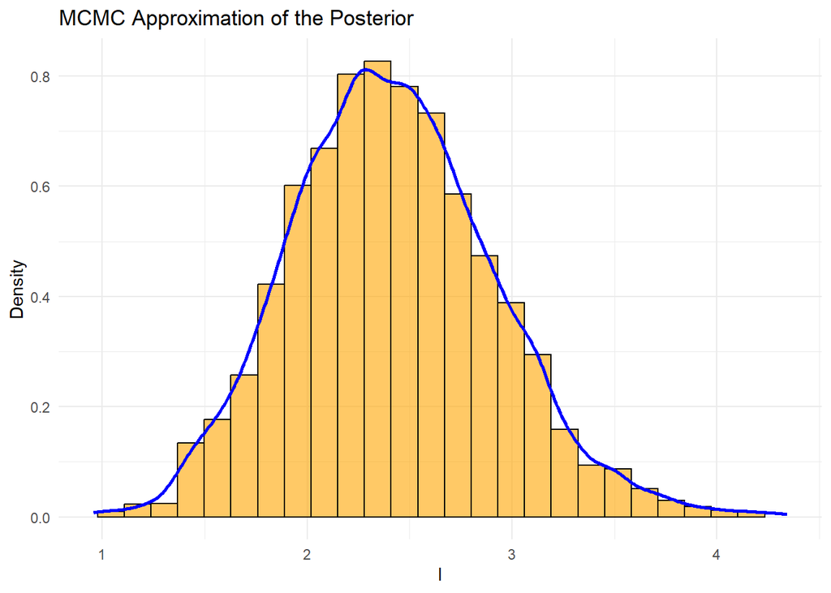

```r
c = C[,2]
# Plot of density function
library(ggplot2)
nbins <- ceiling( (2*n)**(1/3) ) #Terrell-Scott rule for min num bins
ggplot() +
  geom_histogram(aes(x = c, y = ..density..), bins = nbins, fill = "orange", color = "black", alpha = 0.6) +
  geom_density(aes(x = c), color = "blue", linewidth = 1) +
  labs(x = "l", y = "Density", title = "MCMC Approximation of the Posterior") +
  xlim(min(c), max(c)) +
  theme_minimal()
```

## (iii) Implementing a recursive approach in which we consider batches of data in a sequence

First we partition the dataset

```r
#Number of partitions of dataset
k <- 2

#Number of rows
n <- nrow(X)

# Get row group assignments
part_indices <- cut(seq_len(n), breaks = k, labels = FALSE)

# Split row indices instead of splitting X directly
index_groups <- split(seq_len(n), part_indices)

# Turn each group of indices into a matrix
parts_X <- lapply(index_groups, function(idx) X[idx, , drop = FALSE])
y <- matrix(y, ncol = 1)
parts_y <- lapply(index_groups, function(idx) y[idx, , drop = FALSE])
```

**2.1) Prior-recursive Bayesian Inference**

```r
#0) Initial values
a <- 1 #error in proposal distro
N <- 10000 #number of samples
M <- p+1 #dimensions

for (j in range(1,k)) {
  if (j == 1) {
    #Iteration j==1
    #====================
    log_prior <- function(beta) {
      prior = 1
      return(prior)
    }

    #0) Initial values
    b <- matrix(0, nrow = N, ncol = M) #empty matrix to be filled with vals
    b[1,] <- c(0,0)  # first value of beta in the Markov chain is (0,0).

    for (i in 2:N) {
        #1) Propose new position beta[i-1] -> beta[i]' from proposal distro
        b_prop <- proposal(i, M, b, a)

        #2) Compute transition probability
        P_prop <- logistic_ll(b_prop, parts_X$`1`, parts_y$`1`)+log_prior(b_prop)  #P(beta*)
        P_prev <- logistic_ll(b[i-1,], parts_X$`1`, parts_y$`1`)+log_prior(b[i-1])  #P(beta^{i-1})

        #3) Acceptance ratio
        alpha <- min(exp(P_prop - P_prev), 1)

        #3) Generate a random number u_i from [0,1]
        u <- runif(1)  # u_i

        #4)
        if (u <= alpha) {
            b[i,] <- b_prop  # Accept y as next state
        } else {
            b[i,] <- b[i-1,]  # Stay at previous state of Markov chain
        }
    }
    n <- as.integer(0.95 * N)
    C <- b[(N - n + 1):N,] #discard first 5% of samples

    } else {
    #Iteration j > 1
    #====================
    log_prior <- function(beta) {
      prior_d = 1
      d = 1
      while (d < dim(C)[2]) {
        kde = density(C[,d])
        if ( min(C[,d]) < beta[d] && beta[d] < max(C[,d]) ){
          density_at_point = approx(kde$x, kde$y, xout = beta[d])
          prior_d = prior_d * density_at_point$y
        }
        else {
          prior_d = 0
        }
        d = d+1
      }
      prior = log(prior_d)
      return(prior)
    }

    #0) Initial values
    b <- matrix(0, nrow = N, ncol = M) #empty matrix to be filled with vals
    b[1,] <- c(0,0)  # first value of beta in the Markov chain is (0,0).

    for (i in 2:N) {
        #1) Propose new position beta[i-1] -> beta[i]' from proposal distro
        b_prop <- proposal(i, M, b, a)

        #2) Compute transition probability
        P_prop <- logistic_ll(b_prop, parts_X[[j]], parts_y[[j]])+log_prior(b_prop)  #P(beta*)
        P_prev <- logistic_ll(b[i-1,], parts_X[[j]], parts_y[[j]])+log_prior(b[i-1])  #P(beta^{i-1})

        #3) Acceptance ratio
        alpha <- min(exp(P_prop - P_prev), 1)

        #3) Generate a random number u_i from [0,1]
        u <- runif(1)  # u_i

        #4)
        if (u <= alpha) {
            b[i,] <- b_prop  # Accept y as next state
        } else {
            b[i,] <- b[i-1,]  # Stay at previous state of Markov chain
        }
    }
    n <- as.integer(0.95 * N)
    C <- b[(N - n + 1):N,] #discard first 5% of samples
  }
}
```

$\beta_1$ distro estimate:

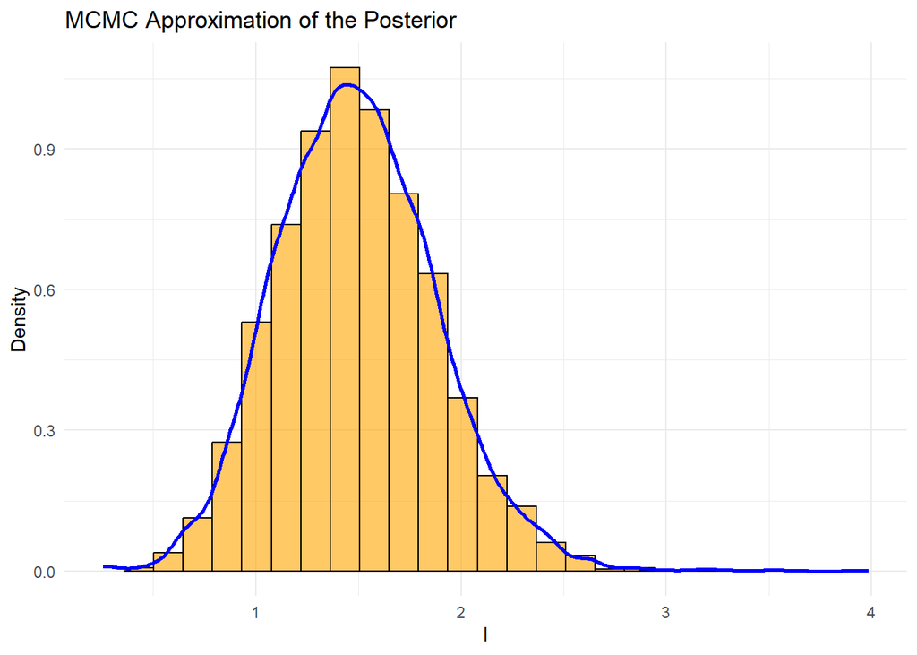

```r
c = C[,1]
# Plot of density function
library(ggplot2)
nbins <- ceiling( (2*n)**(1/3) ) #Terrell-Scott rule for min num bins
ggplot() +
  geom_histogram(aes(x = c, y = ..density..), bins = nbins, fill = "orange", color = "black", alpha = 0.6) +
  geom_density(aes(x = c), color = "blue", linewidth = 1) +
  labs(x = "l", y = "Density", title = "MCMC Approximation of the Posterior") +
  xlim(min(c), max(c)) +
  theme_minimal()
```

$\beta_2$ distro estimate:

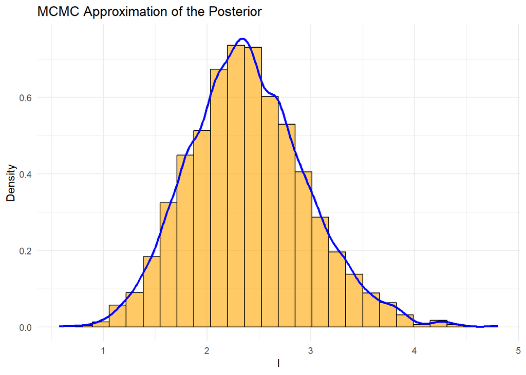

```r
c = C[,2]
# Plot of density function
library(ggplot2)
nbins <- ceiling( (2*n)**(1/3) ) #Terrell-Scott rule for min num bins
ggplot() +
  geom_histogram(aes(x = c, y = ..density..), bins = nbins, fill = "orange", color = "black", alpha = 0.6) +
  geom_density(aes(x = c), color = "blue", linewidth = 1) +
  labs(x = "l", y = "Density", title = "MCMC Approximation of the Posterior") +
  xlim(min(c), max(c)) +
  theme_minimal()
```

```r
#0) Initial values
a <- 1 #error in proposal distro
M <- p+1 #dimensions

for (j in range(1,k)) {
  if (j == 1) {
    #0) Initial values
    N <- 10000 #number of samples
    b <- matrix(0, nrow = N, ncol = M) #empty matrix to be filled with vals
    b[1,] <- c(0,0)  # first value of beta in the Markov chain is (0,0).

    for (i in 2:N) {
        #1) Propose new position beta[i-1] -> beta[i]' from proposal distro
        b_prop <- proposal(i, M, b, a)

        #2) Compute transition probability
        P_prop <- logistic_ll(b_prop, parts_X$`1`, parts_y$`1`) #P(beta*)
        P_prev <- logistic_ll(b[i-1,], parts_X$`1`, parts_y$`1`) #P(beta^{i-1})

        #3) Acceptance ratio
        alpha <- min(exp(P_prop - P_prev), 1)

        #3) Generate a random number u_i from [0,1]
        u <- runif(1)  # u_i

        #4)
        if (u <= alpha) {
            b[i,] <- b_prop  # Accept y as next state
        } else {
            b[i,] <- b[i-1,]  # Stay at previous state of Markov chain
        }
    }
    n <- as.integer(0.95 * N)
    C <- b[(N - n + 1):N,] #discard first 5% of samples

  } else {
    #Iteration j > 1
    #====================

    #0) Initial values
    N <- dim(C)[1] #number of samples
    b <- matrix(0, nrow = N, ncol = M) #empty matrix to be filled with vals
    b[1,] <- C[1,]  # first value of beta in the Markov chain is (0,0).

    for (i in 2:N) {
        #1) Propose new position beta[i-1] -> beta[i]' from proposal distro
        b_prop <- C[i,]

        #2) Compute transition probability
        P_prop <- logistic_ll(b_prop, parts_X[[j]], parts_y[[j]]) #P(beta*)
        P_prev <- logistic_ll(b[i-1,], parts_X[[j]], parts_y[[j]]) #P(beta^{i-1})

        #3) Acceptance ratio
        alpha <- min(exp(P_prop - P_prev), 1)

        #3) Generate a random number u_i from [0,1]
        u <- runif(1)  # u_i

        #4)
        if (u <= alpha) {
            b[i,] <- b_prop  # Accept y as next state
        } else {
            b[i,] <- b[i-1,]  # Stay at previous state of Markov chain
        }
    }
    n <- as.integer(0.95 * N)
    C <- b[(N - n + 1):N,] #discard first 5% of samples
  }
}
```

$\beta_1$ distro estimate:

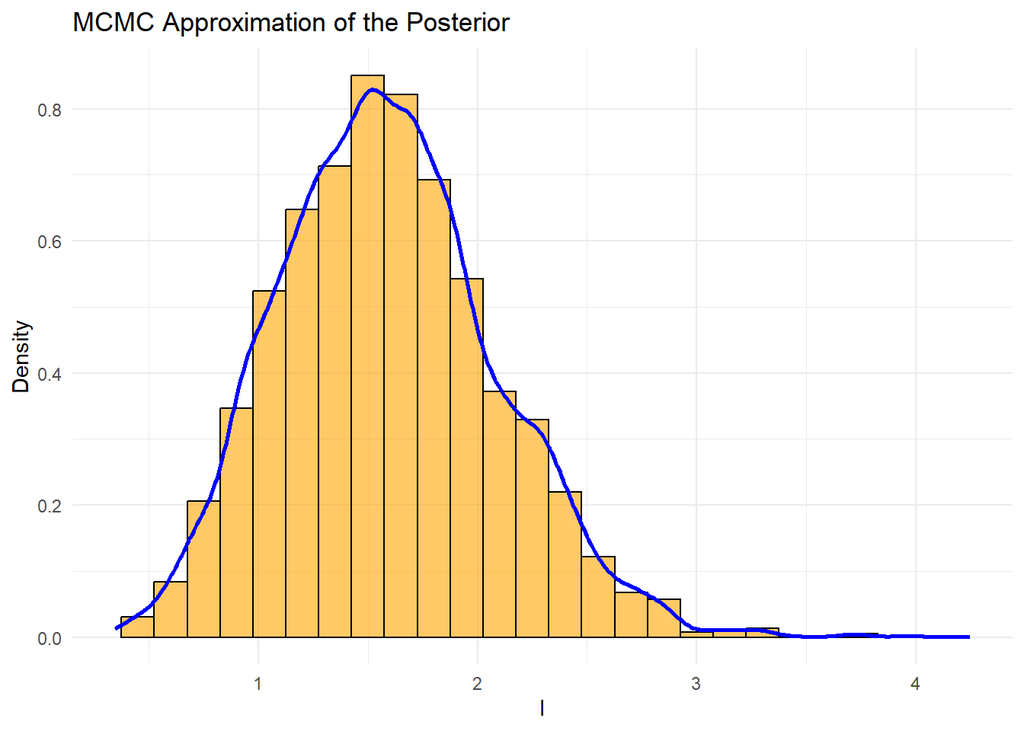

```r
c = C[,1]
# Plot of density function
library(ggplot2)
nbins <- ceiling( (2*n)**(1/3) ) #Terrell-Scott rule for min num bins
ggplot() +
  geom_histogram(aes(x = c, y = ..density..), bins = nbins, fill = "orange", color = "black", alpha = 0.6) +
  geom_density(aes(x = c), color = "blue", linewidth = 1) +
  labs(x = "l", y = "Density", title = "MCMC Approximation of the Posterior") +
  xlim(min(c), max(c)) +
  theme_minimal()
```

$\beta_2$ distro estimate:

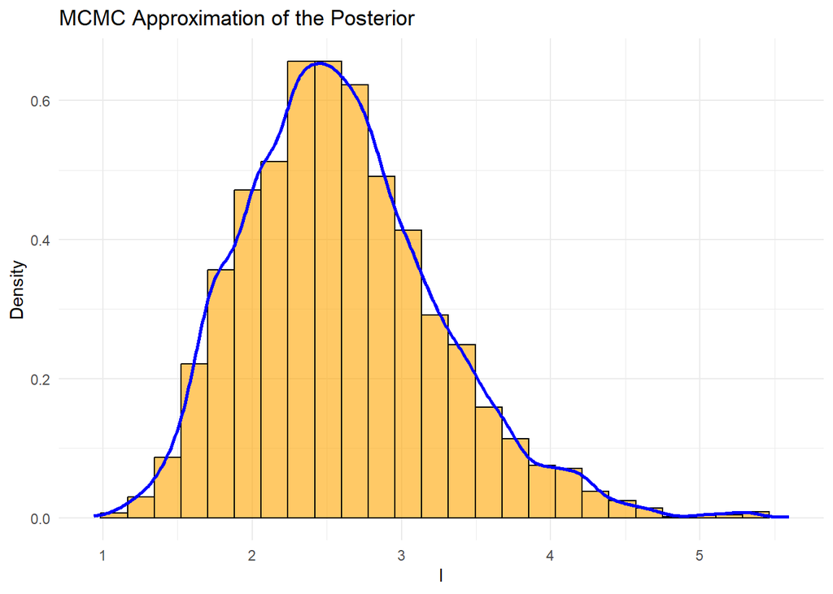

```r
c = C[,2]
# Plot of density function
library(ggplot2)
nbins <- ceiling( (2*n)**(1/3) ) #Terrell-Scott rule for min num bins
ggplot() +
  geom_histogram(aes(x = c, y = ..density..), bins = nbins, fill = "orange", color = "black", alpha = 0.6) +
  geom_density(aes(x = c), color = "blue", linewidth = 1) +
  labs(x = "l", y = "Density", title = "MCMC Approximation of the Posterior") +
  xlim(min(c), max(c)) +
  theme_minimal()
```